# **Tensor Field Network** (and other ConvNet Generalisations)

*TDLS - Feb 11. 2019*

### **Chris Dryden**

- christopher.paul.dryden@gmail.com
- github.com/chrisdryden

### **Peng Cheng**

- pc175@uowmail.edu.au
- github.com/tribbloid

Notebook & sourcecode: https://github.com/tribbloid/convnet-abstraction/tree/master/slide

## **Overview**

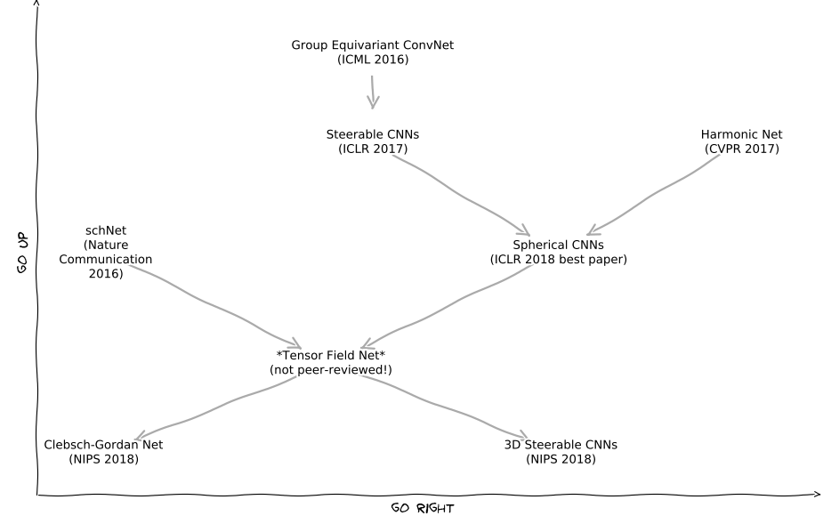

## Pre-ConvNet (1960-1987)

[figure not shown]

## Pre-ConvNet - Linear/Fully Connected/Dense/Perceptron Layer

In pursuing of unbounded representation/approximation power

\begin{align} & f_+(y) = \Phi \Big( f(x) \Big) &= \phi \Big( \sum_{x \in \text{domain}} f(x) w(x, y) \Big) \\ & &= \phi \Big( \bbox[yellow]{< f(x), w(x, y) >_x} \Big) \end{align}

($w$ are weight of neurons)

## Pre-ConvNet - Linear/Fully Connected Layer

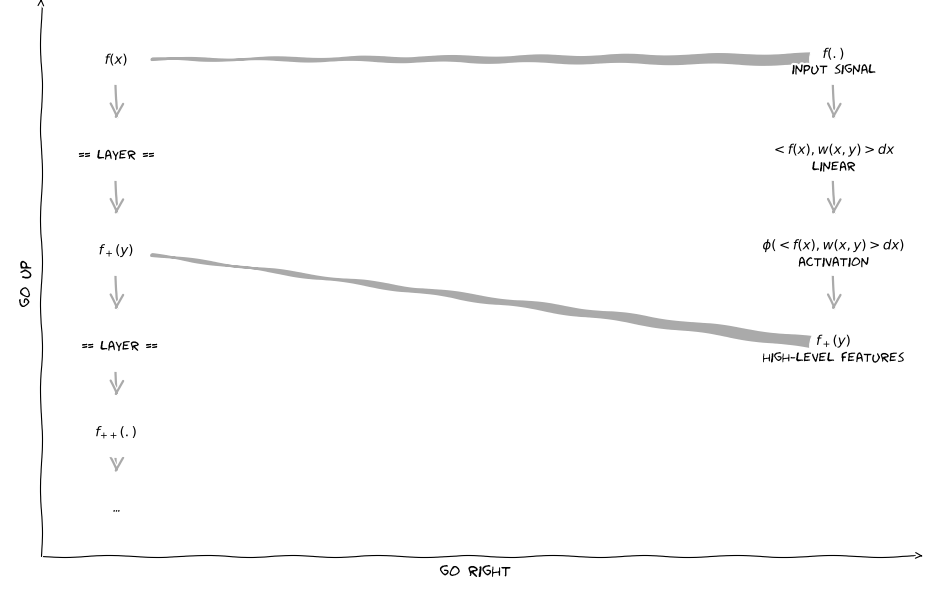

## Pre-ConvNet - Linear/Fully Connected Layer

[figure not shown]

[*] Image courtesy https://www.quora.com/What-is-the-difference-between-equivariance-and-invariance-in-Convolution-neural-networks

## Invariant Layer / Bag-of-words?

- Don't do this

[figure not shown]

[*] Image Courtesy: https://www.amazon.ca/Pablo-Art-Masters-Julie-Birmant/dp/1906838941

## Data Augmentation

- Good catch

[figure not shown]

## Data Augmentation

- Too slow in practice
  - In **convex case** SGD "theoretically probably" converges equally fast
  - otherwise it "kind of works" but with much less efficiency
- Time & space complexity increase exponentially with the dimensionality of augmentation

| 2D translation |
| --- |

## Data Augmentation

- Time & space complexity increase exponentially with the dimensionality of augmentation

| 2D translation x 1D rotation, no gravity |
| --- |

## Data Augmentation

- Time & space complexity increase exponentially with the dimensionality of augmentation

| 2D translation $\times$ 1D rotation, gravity perpendicular to domain |
| --- |

## Data Augmentation

- Time & space complexity increase exponentially with the dimensionality of augmentation

| 3D rotation |
| --- |

## Data Augmentation

- Time & space complexity increase exponentially with the dimensionality of augmentation

| 4D affine transformations |
| --- |

[*] Image Courtesy: AIRR https://thedroneracingleague.com/airr/

## Data Augmentation

- Time & space complexity increase exponentially with the dimensionality of augmentation

| 3D translation $\times$ 3D rotation |
| --- |

## Data Augmentation

- Time & space complexity increase exponentially with the dimensionality of augmentation

| Air pressure depending on translation |
| --- |

## Data Augmentation

How about a better idea?

- Instead of augmenting, we hard-bake such prior knowledge into the network to yield identical result!

| Augmentation types | Answer |
| --- | --- |
| 2d translation | ConvNet |
| **others** | **G-ConvNet** |
| - 2d translation + 90$^{\circ}$ rotation | Group Equivariant CNNs |
| - 2d translation + rotation | Harmonic Net |
| - 3d rotation | Spherical CNNs |
| - 3d translation + rotation | Tensor Field Net |

```
Let's do a hello-world experiment on MNIST dataset:
```

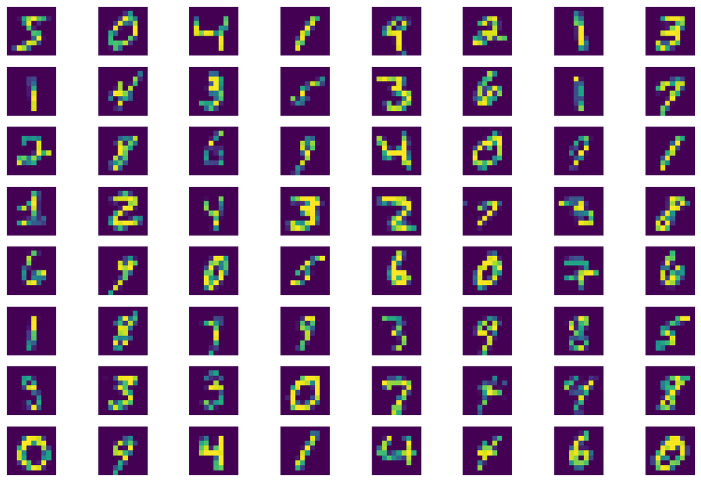

```
... for which each image can be augmented until all cases are covered
```

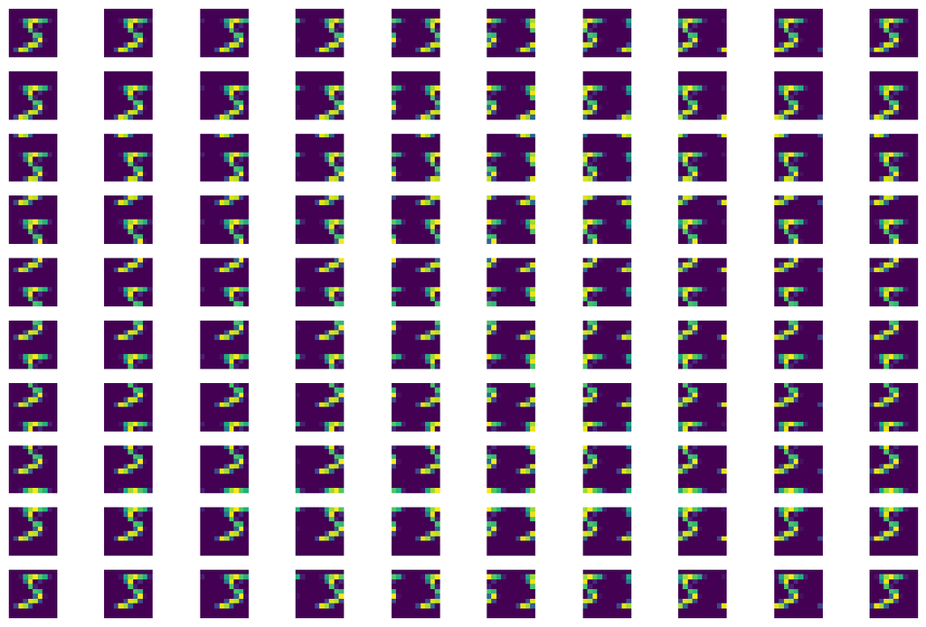

## Start Learning!

### **2 layers only**

1. Highway only bypassing Linear/FC/Dense/Perceptron
   - Designed to break symmetry at saddle points*
   - WITHOUT initialisation (all weights start with 0)
   - 10x10 => 10x10 => ReLU
2. Plain old Linear/FC
   - 10x10 => one-hot 1~10 => ReLU

[*] Y. Li and Y. Yuan, “Convergence Analysis of Two-layer Neural Networks with ReLU Activation” NIPS 2017, pp. 1–11.

## Start Learning!

[figure not shown]

[*] Y. Li and Y. Yuan, “Convergence Analysis of Two-layer Neural Networks with ReLU Activation” NIPS 2017, pp. 1–11.

```
Weight map before training
```

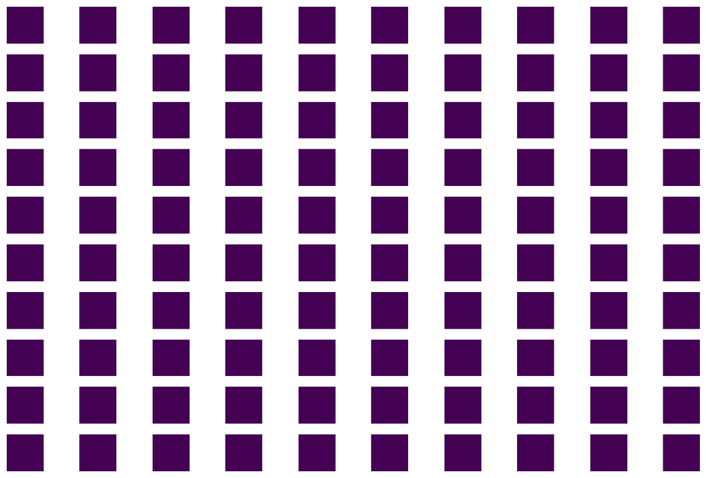

```
Trained on raw MNIST dataset
```

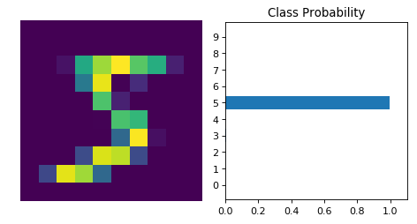

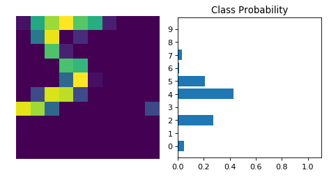

```
Weight map after training on raw MNIST dataset
```

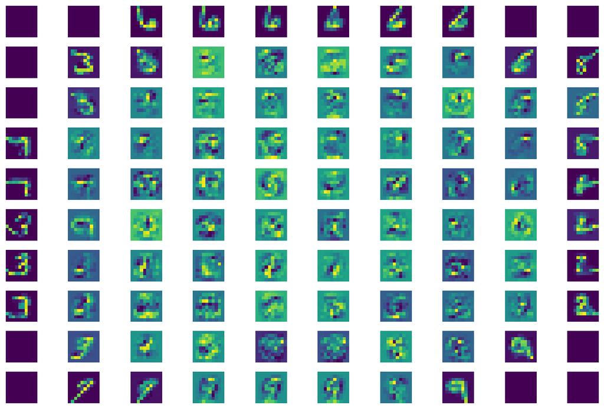

```
Weight map after training on AUGMENTED MNIST dataset
```

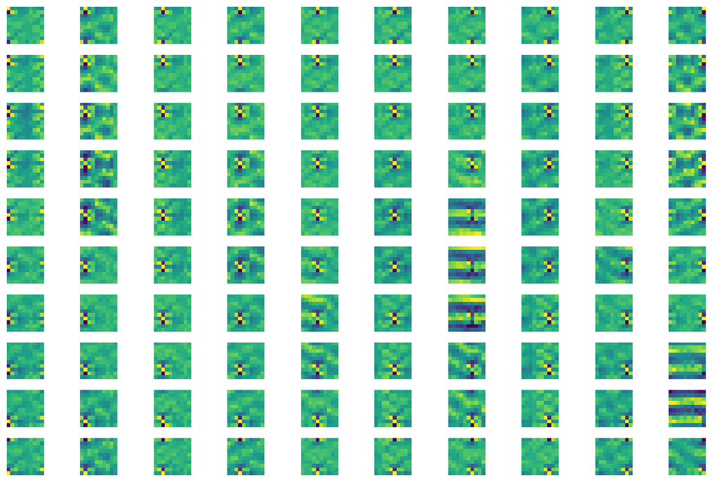

## Data Augmentation

- How did this happen? (you probably want to try this on neural-ODE)

[figure not shown]

## Data Augmentation

- Form a group $\Bigg \{ A_{ug}, U_{ga}, G_{au} ...... \Bigg \}$, sometimes not commutative/Abelian
- $\subset \text{unary operator}: Signal \Longrightarrow Signal $ (making it a group action)
- $\subset \text{**higher-order function**}$

## Data Augmentation

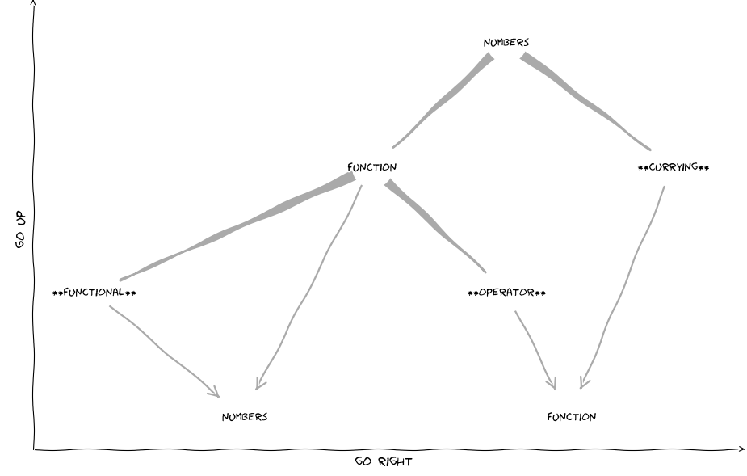

## Data Augmentation $\Longrightarrow$ G-ConvNet

**Lemma**: If the augmentation group $\{ A_{ug} \}$ satisifes:

- **Transitivity**: for any pair of points $x, y$ and any function $f$, we can always find an augmentation that can transform value $f(x)$ to point $y$
- **Group Equivariance**: applying an augmentation $A_{ug}$ on the input has the same effect as applying an augmentation $U_{ga}$ from the same group on the output

Then a fully connected layer:

$$ f_+(y) = <f(x), w(x, y)> _x $$

collapses to a group convolution (**G-conv**) layer:

$$ f_+(y) = < \bbox[yellow]{A_{ug} \circ f(x)}, w_0(x)> _x $$

Looks familiar?

$$ conv(f(- \Delta), w_0(\Delta)) = corr(f(\Delta), w_0(\Delta)) = <\bbox[yellow]{f(\Delta + x)}, w_0(x)> _x $$

## Data Augmentation $\Longrightarrow$ G-ConvNet

$$ f_+(y) = < A_{ug} \circ f(x), w_0(x)> _x $$

In short:

# A ConvNet layer is just an augmented Linear/Fully-Connected layer!

## Data Augmentation - Transitivity

**Transitivity**: for any pair of points $x, y$ and any function $f$, we can always find an augmentation that can transform value $f(x)$ to point $y$

$$ \forall x : f(x) = \Big( A_{ug} \circ f \Big) (x_0) $$

## Data Augmentation - Transitivity

- Effectively means the augmentation group is the 'carriage' to move reference frame around the observer

[figure not shown]

[*] Image courtesy: udacity.com

## Data Augmentation - Equivariance

Plain old **Equivariance**: applying an augmentation $A_{ug}$ on the input has the same effect as applying $A_{ug}$ on the output

$$ A_{ug} \circ f_+(y) = <A_{ug} \circ f(x), w(x, y)> _x $$

## Data Augmentation - Equivariance

- example: SQL prediate pushdown
- example: first input & final output of Masked-CNN & Autoencoder (& maybe Style Transfer)

## Data Augmentation - Group Equivariance

**Group Equivariance**: applying an augmentation $A_{ug}$ on the input has the same effect as applying an augmentation **$U_{ga}$ from the same group** on the output

$$ U_{ga} \circ f_+(y) = <A_{ug} \circ f(x), w(x, y)> _x $$

- Relaxed a bit comparing to Plain old equivariance
- Effectively means that the architecture of the first layer can be carried over to the subsequent layers with little changes, applied on high-level features

## Data Augmentation - Group Equivariance

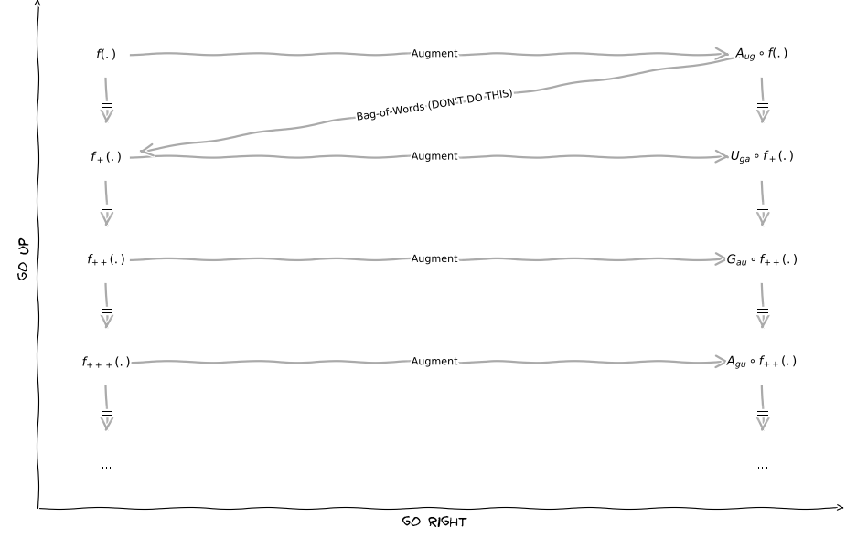

## *Data Augmentation $\Longrightarrow$ G-ConvNet - Proof*

- **Transitivity**:

$$ \forall x : f(x) = \Big( \bar{A}_{ug} \circ f \Big) (x_0) $$

- **Group equivariance**

$$ U_{ga} \circ f_+(y) = <A_{ug} \circ f(x), w(x, y)> _x $$

**Combining all together**:

$$ f_+(y) = \Big( \bar{U}_{ga} \circ f_+ \Big)(y_0) = <\bar{A}_{ug} \circ f(x), w(x, y_0)> _x = <\bbox[yellow]{\bar{A}_{ug} \circ f(x)}, w_0(x)> _x $$

[*] More rigorous proof: R. Kondor and S. Trivedi, “On the Generalization of Equivariance and Convolution in Neural Networks to the Action of Compact Groups” 2018

## G-ConvNet

$$f_+(y) = <A_{ug} \circ f(x), w_0(x)> _x$$

- this implies bijection/isomorphism $y \longleftrightarrow A_{ug}$
- ... and high-level features usually have more dimensions $\{x\} \subset \{y\}$

All of the followings are concrete subclasses:

| Augmentation types | Answer |
| --- | --- |
| 2d translation | ConvNet |
| **others** | **G-ConvNet** |
| - 2d translation + 90$^{\circ}$ rotation | Group Equivariant CNNs |
| - 2d translation + rotation | Harmonic Net |
| - 3d rotation | Spherical CNNs |
| - 3d translation + rotation | Tensor Field Net |

## ConvNet

| - | Input $f(x)$ | High-level $f_+(y)$, $f_{++}(z)$, ... | Augmentation $A_{ug}$, $U_{ga}$, ... |
| --- | --- | --- | --- |
| domain | $R^2$ | $R^2$ | $R^2$ (translation only) |

- First of its kind but not the last
- A rare case when high-level feature domain $\{y\} = \{x\}$, in all other cases $\{y\} \supset \{x\}$

[figure not shown]

## ConvNet

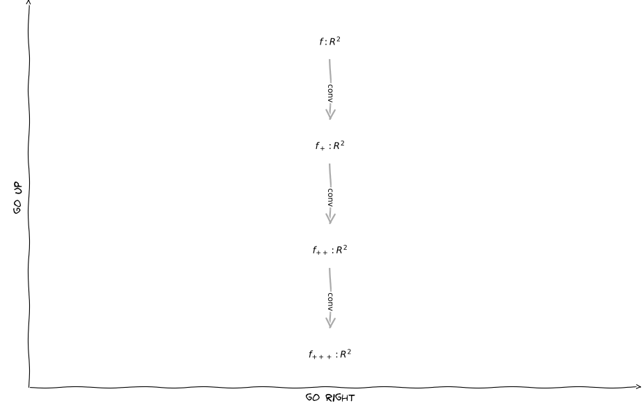

## Group Equivariant CNNs (ICML 2016*)

| - | Input $f(x)$ | High-level $f_+(y)$, $f_{++}(z)$, ... | Augmentation $A_{ug}$, $U_{ga}$, ... |
| --- | --- | --- | --- |
| domain | $R^2$ | $R^2 \times p4$ | $R^2 \times p4$ (translation, rotation $\pm 90^{\circ}$) |

- change looks trivial

[figure not shown]

[*] T. S. Cohen and M. Welling, “Group Equivariant Convolutional Networks,” ICML 2016.

## Group Equivariant CNNs (ICML 2016*)

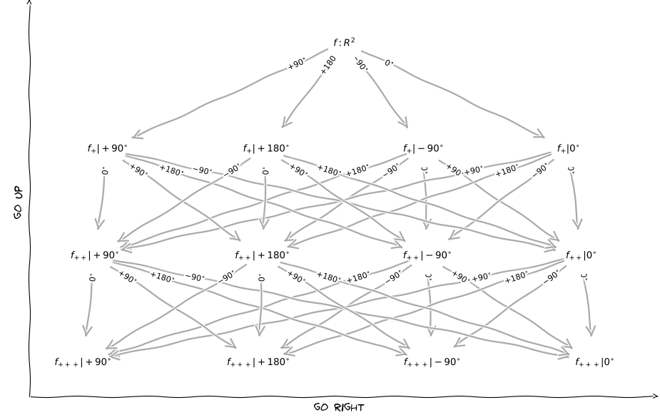

## Group Equivariant CNNs (ICML 2016*) - Alternatively

| - | Input $f(x)$ | High-level $f_+(y)$, $f_{++}(z)$, ... | Augmentation $A_{ug}$, $U_{ga}$, ... |
| --- | --- | --- | --- |
| domain | $R^2$ | $R^2 \times p4m$ | $R^2 \times p4m$ (translation, rotation $\pm 90^{\circ}$, flipping) |

- Size of filter bank start to become annoying, but still acceptable.

[figure not shown]

[*] T. S. Cohen and M. Welling, “Group Equivariant Convolutional Networks,” ICML 2016.

## Harmonic Net (CVPR 2017*)

| - | Input $f(x)$ | High-level $f_+(y)$, $f_{++}(z)$, ... | Augmentation $A_{ug}$, $U_{ga}$, ... |
| --- | --- | --- | --- |
| domain | $R^2$ | $O(2)$ | $O(2) \cong R^2 \times SO(2)$ (translation, arbitrary rotation) |

- Size of the filter bank become intolerably big, can't take it any more
- First algorithm to use **spectral decomposition as a weight compressor**

[*] D. E. Worrall, S. J. Garbin, D. Turmukhambetov, and G. J. Brostow, “Harmonic Networks: Deep Translation and Rotation Equivariance” CVPR 2017, vol. 2017–Jan, pp. 7168–7177.

## Going Spectral

- function is like infinite-dimension vector
- Spectral decomposition for functions is like eigen-decomposition for vectors

*orthonormal basis*: given a function domain $X \longrightarrow C$, there may exist a (likely infinite) series of bases ${u_1, u_2, ...}$ that are both:

- **complete**: linear combination can approximate arbitrary function on the domain

$$ f(.) = \sum_{\forall m} \phi_m u_m(.) = \Big[ \phi_1, \phi_2, ... \Big] \begin{bmatrix} u_1(.) \\ u_2(.) \\ ... \end{bmatrix} $$

## Going Spectral

- function is like infinite-dimension vector
- Spectral decomposition for functions is like eigen-decomposition for vectors
- and **orthonormal**: have unit norms and orthogonal to each other

$$ <u_m(.), u_n(.)> = I_{mn} \text{ (Kronecker delta)} $$

- ... which implies:

$$ \phi_m = \widehat{f}(m) = <f(.), u_m(.)> \text{ (GFT)} $$

## Going Spectral - What's the point?

It makes a few things easier:

- Convolution theorem still works in most cases! a.k.a. **G-conv theorem**

$$ \widehat{f_+}(m) = < \widehat{A_{ug}}(m) \circ \widehat{f}(m), \widehat{w_0}(m) >_m $$

(This makes dot product and G-conv much faster)

- Most G-ConvNet features are smooth on all dimensions

(This means low-frequency coefficients can compress high-dimension filter banks)

## *G-conv Theorem - Proof*

\begin{align} & & f_+(y) &= <A_{ug} \circ f(x), w_0(x)>_x \\ & & &= \sum_m \sum_n \widehat{A_{ug} \circ f}(m) \widehat{w_0}(j) <u_m(.), u_n(.)> \\ &\text{(orthonormal)} & &= \sum_m \widehat{A_{ug} \circ f}(m) \widehat{w_0}(m) \\ &\text{(GFT)} & &= \sum_m < A_{ug} \circ f(x), u_m(x) >_x \cdot < w_0(x), u_m(x) >_x \end{align}

[*] More rigorous proof for $SO(3)$ case: T. S. Cohen, M. Geiger, J. Koehler, and M. Welling, “Spherical CNNs,” no. 3, pp. 1–15, 2018.

## *G-conv Theorem - Proof*

If luckily $A_{ug}$ is linear:

\begin{align} &\text{(bijectory)} & \widehat{f_+}(n) &= \sum_m \Big< < \bbox[yellow]{A_{ug}(y)} \circ f(x), u_m(x) >_x \Big| u_n(y) \Big>_y \cdot < w_0(x), u_m(x) >_x \\ &\text{(linear)} & &= \sum_m < u_n(y), A_{ug}(y)>_y \circ < f(x), u_m(x) >_x \cdot < w_0(x), u_m(x) >_x \\ & & &= < \widehat{A_{ug}}(n) \circ \widehat{f}(m), \widehat{w_0}(m) >_m\\ & \text{(IFF $A_{ug}$ is distance-preserving)} & &= <\widehat{f}(m), \widehat{A_{ug}^{-1}}(n) \circ \widehat{w_0}(m) >_m \end{align}

## Harmonic Net (CVPR 2017*)

| - | Input $f(x)$ | High-level $f_+(y)$, $f_{++}(z)$, ... | Augmentation $A_{ug}$, $U_{ga}$, ... |
| --- | --- | --- | --- |
| domain | $R^2$ | $O(2)$ | $O(2) \cong R^2 \times SO(2)$ (translation, arbitrary rotation) |

- $u_m(x) \longleftarrow e^{m x}$ (2D Fourier series, x is a complex number)
- GFT $\longleftarrow$ FFT (with Gaussian resampling)
- number of coefficients $\longleftarrow 2$: $m \in {0, 1}$

[*] D. E. Worrall, S. J. Garbin, D. Turmukhambetov, and G. J. Brostow, “Harmonic Networks: Deep Translation and Rotation Equivariance” CVPR 2017, vol. 2017–Jan, pp. 7168–7177.

## Harmonic Net (CVPR 2017*)

Orthonormal bases (without radial):

[figure not shown]

[*] D. E. Worrall, S. J. Garbin, D. Turmukhambetov, and G. J. Brostow, “Harmonic Networks: Deep Translation and Rotation Equivariance” CVPR 2017, vol. 2017–Jan, pp. 7168–7177.

## Harmonic Net (CVPR 2017*)

Orthonormal bases (with radial):

[figure not shown]

[*] Image courtesy: C. E. Coleman-Smith, H. Petersen, and R. L. Wolpert, “Classification of initial state granularity via 2d Fourier Expansion” Apr. 2012.

## Harmonic Net (CVPR 2017*)

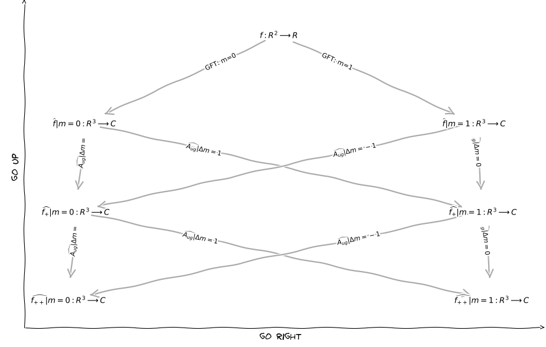

## Spherical CNNs (ICLR 2018* best paper)

You can use many cameras for situation awareness

[figure not shown]

[*] Image Courtesy: https://www.tesla.com/en_CA/autopilot

## Spherical CNNs (ICLR 2018* best paper)

... Or you can use few fisheye camera(s)

[figure not shown]

[*] Image courtesy: DJI-X https://www.halfchrome.com/dji-360-drone/

## Spherical CNNs (ICLR 2018* best paper)

Instead ...

[figure not shown]

[*] Image Courtesy: Skydio R1 https://www.skydio.com/technology/

## Spherical CNNs (ICLR 2018* best paper)

Instead ...

[figure not shown]

[*] Image Courtesy: Skydio R1 https://www.skydio.com/technology/

## Spherical CNNs (ICLR 2018* best paper)

| - | Input $f(x)$ | High-level $f_+(y)$, $f_{++}(z)$, ... | Augmentation $A_{ug}$, $U_{ga}$, ... |
| --- | --- | --- | --- |
| domain | $S^2$ | $SO(3)$ | $SO(3) \cong SU(2)$ (3d rotation) |

- $u_m(x) \longleftarrow D_m(x)$ (Wigner-D function, $x$ is an Euler-angle tuple or quaternion)
  - collapses to spherical harmonics on the first layer
- GFT $\longleftarrow$ SO(3) FFT
- number of coefficients $\leq 25$: $l \in [0, 4]$ (increasing beyond that contributes little to accuracy)

[*] T. S. Cohen, M. Geiger, J. Koehler, and M. Welling, “Spherical CNNs,” no. 3, pp. 1–15, 2018.

## Spherical CNNs (ICLR 2018* best paper)

| - | Input $f(x)$ | High-level $f_+(y)$, $f_{++}(z)$, ... | Augmentation $A_{ug}$, $U_{ga}$, ... |
| --- | --- | --- | --- |
| domain | $S^2$ | $SO(3)$ | $SO(3) \cong SU(2)$ (3d rotation) |

[figure not shown]

[*] T. S. Cohen, M. Geiger, J. Koehler, and M. Welling, “Spherical CNNs,” no. 3, pp. 1–15, 2018.

## Spherical CNNs (ICLR 2018* best paper)

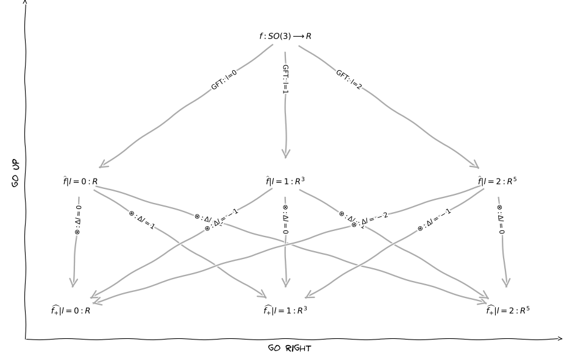

## Tensor Field Network (Not Peer Reviewed!)

| - | Input $f(x)$ | High-level $f_+(y)$, $f_{++}(z)$, ... | Augmentation $A_{ug}$, $U_{ga}$, ... |
| --- | --- | --- | --- |
| domain | $R^3$ | $O(3)$ | $O(3) \cong R^3 x SO(3)$ (3d translation & rotation) |

- $u_m(x) \longleftarrow D_m(x)$ (Wigner-D function, $x$ is an Euler-angle tuple or quaternion)
  - collapses to spherical harmonics on the first layer
- GFT $\longleftarrow$ SO(3) FFT
- number of coefficients $\longleftarrow 4$: $l \in {0, 1}$
- C-G transformation is used to accelerate G-conv in frequency space
  - which was not needed in Spherical CNNs due to lack of radial component

## Tensor Field Network (Not Peer Reviewed!)

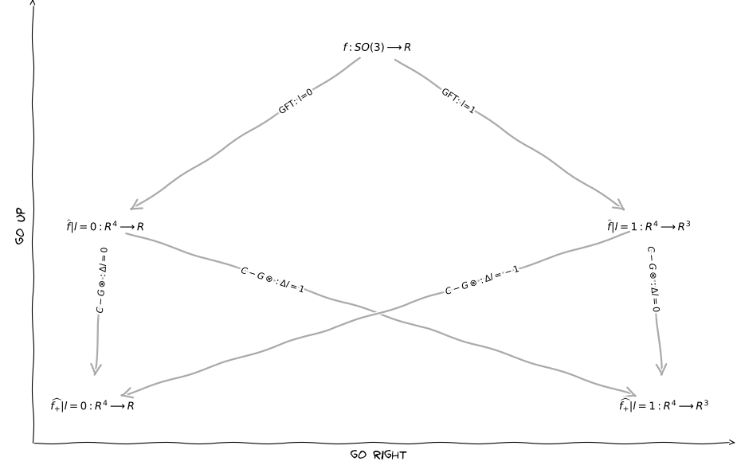